# BC Stats Proposal

April 26, 2019

## Introduction

### Background

- Work Environment Survey (WES)

**Primary goals:**

- Understand employee experiences
- Celebrate successes
- Identify improvements

[figure not shown]

## Introduction

### Data

There are over 15,000 respondants across 26 ministries and over 8 survey cycles starting in 2007. All of the Survey data can be categorized in two:  
Quantitative data (Likert Scale questions)

Qualitative data (comments/open ended responses)

## Introduction

### Quantitative Data

Approximatley 80 quantitative questions all related to **day-to-day work, management, performance, pay & benefits, etc.**

Examples:

- A healthy atmosphere exists in my work unit: [1-5]
- The quality of training and development I have received is satisfactory: [1-5]

## Introduction

### Quantitative Data

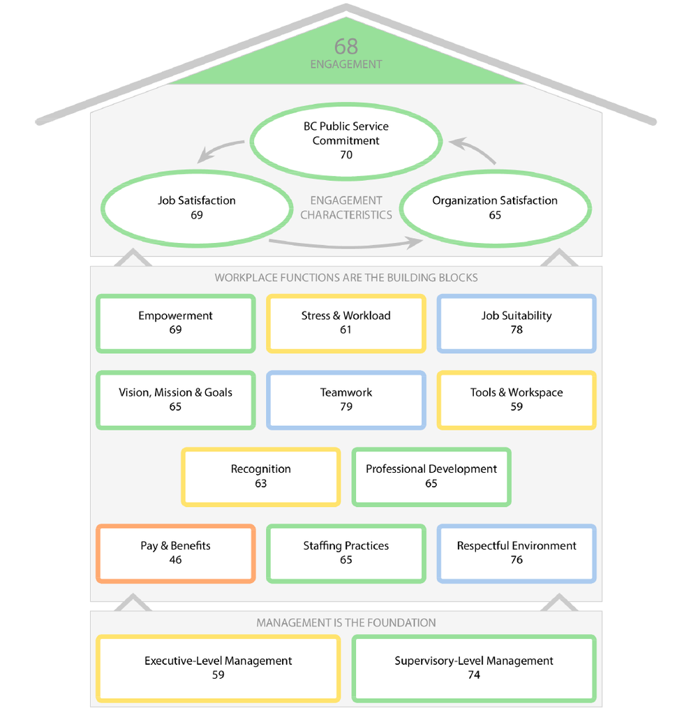

The current quantitative analysis report includes:

- aggregated multiple choice answers by ministry
- aggregated multiple choice answers overall
- engagement model highlighting key drivers

## Introduction

### Qualitative Data

**What one thing would you like your organization to focus on to improve your work environment?**

Example Themes:

- Compensation and Benefits
- Stress and Workload
- Supervisors
- etc.

## Introduction

### Qualitative Data

**Example Comment**:  
*“Some work units have the latest laptop/tablets/ while others are still using old/outdated technology. Please provide fair and equal access to tools. If one unit gets an upgrade, please provide to all units.”*  
**Theme**: Tools, Equipment & Physical Environment  
**Sub-theme**: Provide better computer-based hardware

## Introduction

### Qualitative Data

The current qualitative analysis report includes:

- manual coding of comments into 12 themes and ~60 sub-themes
- ranking areas of improvement overall and by ministry

## Introduction

### Qualitative Data

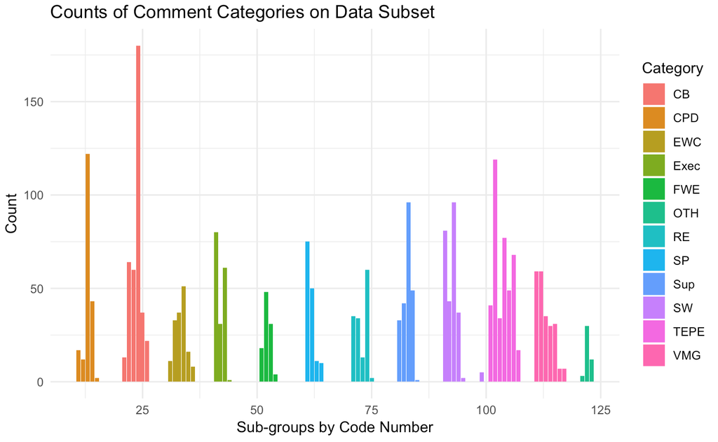

## Research Question

**1. Coding Themes** - What is the best method to code the themes and sub-themes to the qualitative responses?

**2. Linking Quantitative to Qualtitative** - How well does the sentiment of the qualitative responses agree with the quantitative responses?

**3. Trends** - What trends in key engagement drivers and multiple choice questions exist over time and across departments from the 2008 to 2018 quantitative survey data?

## Data Science Techniques

### **1. Coding Themes**

**Approach:**

- Themes are previously specified and labeled (Supervised Learning)
- Base Model: Bag of words and SVM Classification
- Complex Model: Multiclass and Multilabel ensemble classification models

**Challenges:**

- 60+ levels in Classification
- Multiple levels can apply to one comment

**Deliverables:**

- Trained Model for future labelling

## Data Science Techniques

### **2. Linking Quantitative to Qualtitative**

**Approach:**

- Sentiment Analysis and Emotion Recognition [Ref.](https://en.wikipedia.org/wiki/Emotion_recognition)

Inter-rater reliability Metrics:

- Percent agreement calculation
- Cohen's kappa
- Krippendorff's alpha

**Challenges:**

- Comments may lack sentiment
- Or are primarily negative

**Deliverables:**

- Report
- Dashboard

## Data Science Techniques

### **3. Trends Across Ministries and Overtime**

**Approach:**

- Descriptive statistics and visualization
- Base Model: Moving Average
- Complex Model: Regression analysis

**Challenges:**

- Messy data and inconsistent survey questions over time

**Deliverables:**

- Dashboard

## Timeline

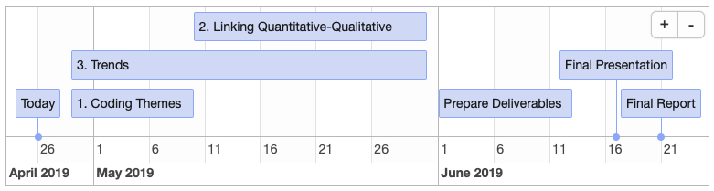